# GEOG456_Discharge&Precipitation_Compared

Anna Cherry and Nick Furigay

1/28/2020

## Importing USGS Data

This section lays out the steps for importing data into R from the USGS database. This data is for the Tar River Basin in Pitt County, NC and spans 2015-2020.

1. This line fetches the precip data from the USGS online database and the dates can be altered in the address.

```r
rainYear = "https://nwis.waterdata.usgs.gov/nc/nwis/uv/?cb_00045=on&format=rdb&site_no=02084000&period=&begin_date=2015-01-01&end_date=2020-01-01"
```

2.This line fetches the discharge data from the USGS online database and the dates can be altered in the address.

```r
flowYear  = "https://nwis.waterdata.usgs.gov/nc/nwis/uv/?cb_00060=on&format=rdb&site_no=0209734440&period=&begin_date=2015-01-01&end_date=2020-01-01"
```

After the data is imported from USGS, the data must be formatted into tables for further use.

```r
t1 <- read.table(rainYear,skip=30,header=F, colClasses=c("character", "character", "character", "character", "character","numeric"), na.strings=c("NA", "-", "?", "***", "Eqp", "10s"))

t2 <- read.table(flowYear,skip=30,header=F, colClasses=c("character", "character", "character", "character", "character","numeric"), na.strings=c("NA", "-", "?", "***", "Eqp", "10s"))
```

5. This renames the columns with titles that can be used in the future code and are better describers of the information in the column

```r
daNames = c('agency', 'id', 'date','time','tz', 'prcp', 'flag')
daNamesFlow =  c('agency', 'id', 'date','time','tz', 'flow', 'flag')

#Application of the new column names to table 1
names(t1) = daNames
#Application of the new column names to table 2
names(t2) = daNamesFlow
```

## Making Plots

1.Add all the data points every 15 seconds for one date together to create daily points of summed precipitation and discharge *Remember that which data sets are labeled t1 and t2

```r
t1DailySum = aggregate(prcp ~ date, data = t1, sum)

t2DailySum = aggregate(flow ~ date, data = t2, sum)
```

1.1 The two databases can be combined into one table by their shared ID date

```r
tall = merge(x = t1DailySum, y = t2DailySum, by.x = 'date', by.y = 'date')
```

2.open the ggplot library

```r
library(ggplot2)
```

3. Create a plot using the ggplot library which uses the sums of the daily precipitation. The axes are labeled and uses the bar chart format

```r
p <- ggplot(t1DailySum, aes(x=date, y=prcp)) + geom_bar(stat="identity")
```

4. Create a plot using the ggplot library which fills the bar chart with color and gives the plot a title and alters the y-axis limit

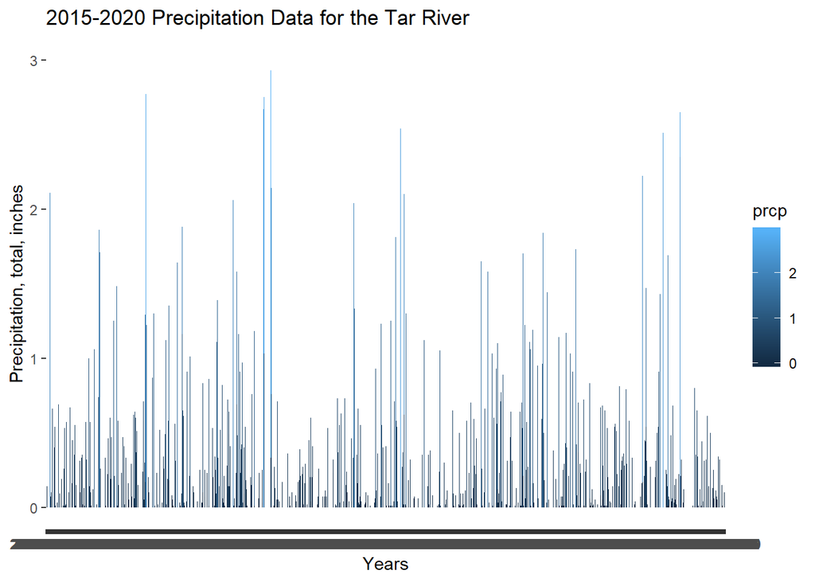

```r
p <- p +ggtitle("2015-2020 Precipitation Data for the Tar River") + labs(y= "Precipitation, total, inches", x = "Years") + aes(fill = prcp) + ylim(0,3)
p
```

5.Create a plot using the ggplot library which uses the sums of the daily discharge. The axes are labeled and uses the bar chart format

```r
f <- ggplot(t2DailySum, aes(x=date, y=flow)) + geom_bar(stat="identity")
```

6. Creating a plot using the ggplot library which fills the bar chart with color and gives the plot a title and alters the y-axis limit

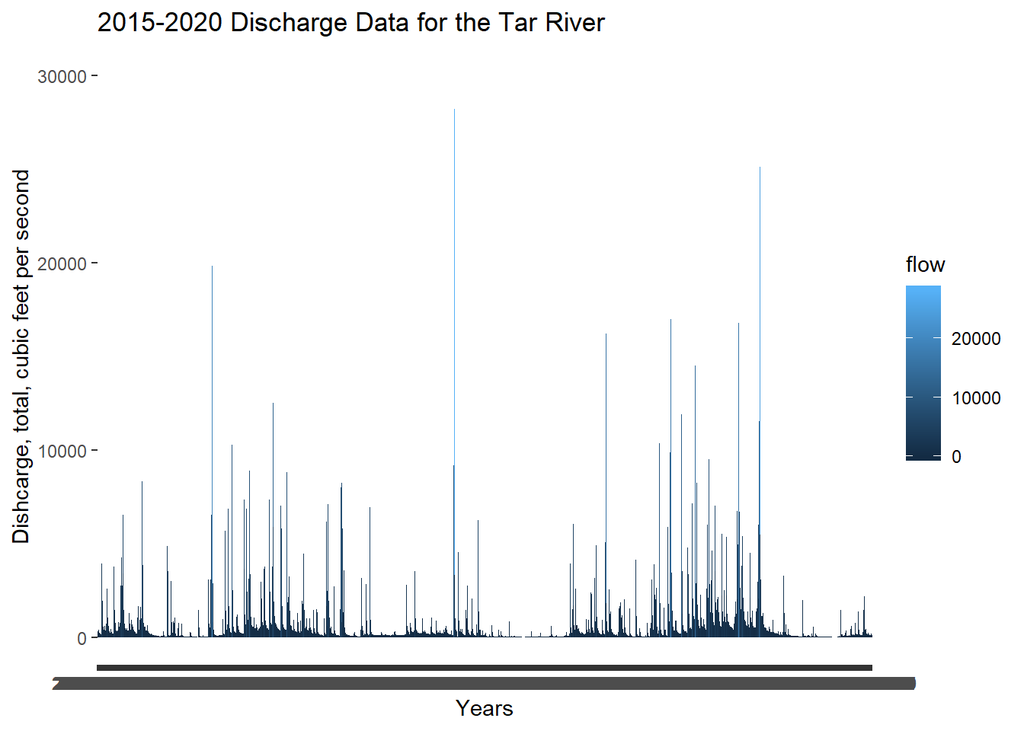

```r
f <- f +ggtitle("2015-2020 Discharge Data for the Tar River") + labs(y= "Dishcarge, total, cubic feet per second", x = "Years") + aes(fill = flow)+ ylim(0,30000)
f
```

## Making the Visuals Better

Creating an inverted plot of precipitation

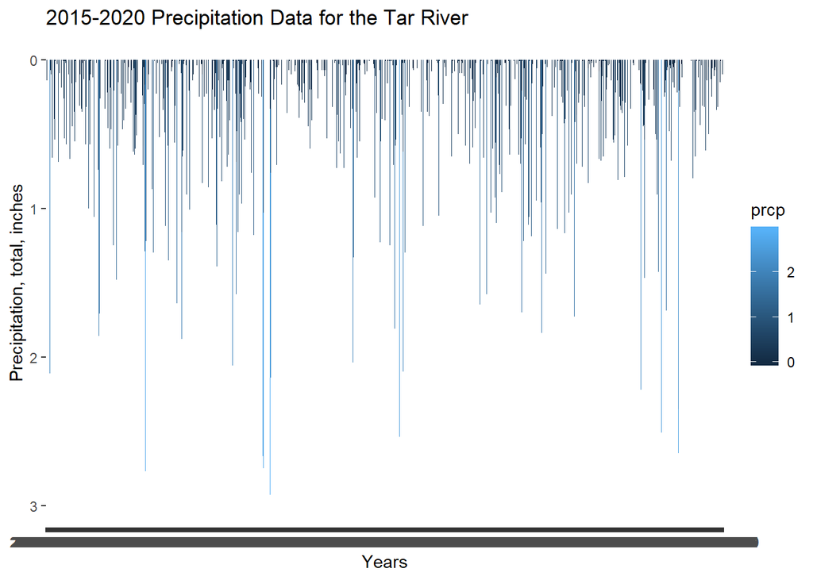

```r
q <- ggplot(t1DailySum, aes(x=date, y=prcp)) + geom_bar(stat="identity") + scale_y_reverse()+ ylim(3,0) +ggtitle("2015-2020 Precipitation Data for the Tar River") + labs(y= "Precipitation, total, inches", x = "Years") + aes(fill = prcp)
q
```

Combining both plots onto one page, one below the other. (Switch rows and columns if you want them side by side)

```r
#install.packages("ggpubr")
#library(ggpubr())
#figure <- ggarrange(q, f,
#                    labels = c("A", "B"),
#                   ncol = 1, nrow = 2)
#figure
```

image:

[figure not shown]